# A Hub That Orders in Batches

Manuel D. Rossetti, PhD P.E.

## Agenda

- What batching changes, and the one move that carries the chapter
- A hub and a storeroom run together by hand, one event at a time
- The hub as a chapter 8 location, and the wait it imposes: mean, distribution, second moment
- Axsäter’s exact recursion, and three routes to a storeroom’s lead time demand priced against it

## One Assumption Did the Work

Chapter 9 solved two levels under one-for-one ordering: the demand a location passes up is its own demand, arrival for arrival. **This chapter removes that.** A storeroom ordering $Q_j$ at a time sends one request per $Q_j$ customers: nothing for a while, then $Q_j$ at once.

Three things change at the hub:

1. **Its demand is no longer the customers’.** Lumpier, and more regular in its timing.
2. **An order waits for its last unit.** Two on the shelf and an order of three: ship two, owe one.
3. **The policies cannot be set one after the other.** The hub’s demand depends on $Q_j$, and the storeroom’s lead time depends on the hub.

**One move carries the chapter**

**Condition on the position, then average.** Chapter 8 built $\bar{B}(r, Q)$ by averaging base-stock measures over $Q$ equally likely positions. The chapter makes that move four more times.

What does not change: Little’s Law turns a supplier’s backorders into a delay, averaged over every request.

## The Item and the Network

The fuse cutout, at a hub and four identical storerooms. **In Parts I and II each customer takes one unit**; the job lots return in Part III.

| Question | Answer |
| --- | --- |
| *What is stocked?* | One item, the fuse cutout, at five locations |
| *What is the demand process?* | Poisson, one unit a week at each storeroom |
| *When is inventory reviewed?* | Continuously, everywhere |
| *What triggers replenishment, and how much?* | Storerooms: every customer, base stock $S_j = 3$. Hub: position at $r_0 = 9$, order $Q_0 = 8$ |
| *What happens to unmet demand?* | Backordered at both levels, first come first served, part orders shipped |
| *What costs are incurred, and when?* | Holding $h$ at both levels, shortage $b$ at storerooms only |

$$h = \frac{\$28.75}{\text{unit-year}} \times \frac{1 \text{ year}}{52 \text{ weeks}}
= \$0.5529, \qquad b = \frac{\$287.50}{52} = \$5.5288 \text{ per unit-week}$$

## Working Two Locations by Hand

**One row per event, at the week it occurs, state recorded after posting.** When two events share a week: **the hub’s receipts first, then the storeroom’s, then demands in order.**

**Hub:** $(r_0, Q_0) = (1, 4)$, $L_0 = 3$ weeks, starts with 5.

**Storeroom:** base stock $S_j = 2$, $O_j = 1$ week, starts with 2.

**Failures** in weeks 1, 3, 6, 8, 9, 10 and 14; a storm in week 8 takes out three, so week 8 has three failures.

*The check on every row.* At the hub,

$$\mathit{IP}_0 = I_0 + \text{on order} - B_0$$

and at the storeroom, on-hand less backorders plus in transit plus what the hub still owes. Compute both ways; stop when they disagree.

## Weeks 1 to 8: the Storm

| Week | Event | $I_j$ | $B_j$ | $\mathit{IP}_j$ | In transit | $I_0$ | $B_0$ | On order | $\mathit{IP}_0$ |
| --- | --- | --- | --- | --- | --- | --- | --- | --- | --- |
| 0 | start | 2 | 0 | 2 | 0 | 5 | 0 | 0 | 5 |
| 1 | failure, request to hub | 1 | 0 | 2 | 1 | 4 | 0 | 0 | 4 |
| 2 | storeroom receives 1 | 2 | 0 | 2 | 0 | 4 | 0 | 0 | 4 |
| 3 | failure, request to hub | 1 | 0 | 2 | 1 | 3 | 0 | 0 | 3 |
| 4 | storeroom receives 1 | 2 | 0 | 2 | 0 | 3 | 0 | 0 | 3 |
| 6 | failure, request to hub | 1 | 0 | 2 | 1 | 2 | 0 | 0 | 2 |
| 7 | storeroom receives 1 | 2 | 0 | 2 | 0 | 2 | 0 | 0 | 2 |
| 8 | failure, request to hub, **hub orders 4** | 1 | 0 | 2 | 1 | 1 | 0 | 4 | 5 |
| 8 | failure, request to hub | 0 | 0 | 2 | 2 | 0 | 0 | 4 | 4 |
| 8 | failure, request **backordered** | 0 | **1** | 2 | 2 | 0 | **1** | 4 | 3 |

## Weeks 9 to 15: One Delivery, Three Requests

| Week | Event | $I_j$ | $B_j$ | $\mathit{IP}_j$ | In transit | $I_0$ | $B_0$ | On order | $\mathit{IP}_0$ |
| --- | --- | --- | --- | --- | --- | --- | --- | --- | --- |
| 8 | (carried from the last slide) | 0 | 1 | 2 | 2 | 0 | 1 | 4 | 3 |
| 9 | storeroom receives 2, serves the waiting crew | 1 | 0 | 2 | 0 | 0 | 1 | 4 | 3 |
| 9 | failure, request backordered | 0 | 0 | 2 | 0 | 0 | 2 | 4 | 2 |
| 10 | failure backordered, request backordered, **hub orders 4** | 0 | 1 | 2 | 0 | 0 | 3 | 8 | 5 |
| 11 | hub receives 4, **fills three waiting requests** | 0 | 1 | 2 | 3 | 1 | 0 | 4 | 5 |
| 12 | storeroom receives 3, serves the waiting crew | 2 | 0 | 2 | 0 | 1 | 0 | 4 | 5 |
| 13 | hub receives 4 | 2 | 0 | 2 | 0 | 5 | 0 | 0 | 5 |
| 14 | failure, request to hub | 1 | 0 | 2 | 1 | 4 | 0 | 0 | 4 |
| 15 | storeroom receives 1 | 2 | 0 | 2 | 0 | 4 | 0 | 0 | 4 |

## What the Ledger Establishes

**The mean wait, two ways.** Follow the nine requests: six waited nothing, and those from weeks 8, 9 and 10 waited 3, 2 and 1 weeks, so $6/9 = 0.667$ weeks. Weight the hub’s backorders by duration: $1 + 2 + 3 = 6$ unit-weeks over the nine requests, the same 0.667. That is Little’s Law.

**The three waits of week 11 are one event.** One delay, seen three times, not three independent draws. For a base-stock storeroom that turns out not to matter, and we will see why.

**The crews waited because the hub did.** The storeroom’s stock never changed; its two shortages were manufactured by a storm draining a hub that had been spending its stock one unit at a time.

**A request arriving with the hub’s position high waits nothing.** In weeks 1 to 7 the position was 4, 3 or 2 and every request shipped at once. Whether a request waits depends on where the hub’s position sits when it arrives.

## The Hub Is a Chapter 8 Problem

One-at-a-time storerooms send one request per customer, so four Poisson streams merge into a Poisson stream at $\lambda_0 = 4$. The hub is the $(r, Q)$ location of chapter 8, and its measures come with no change. $D_0(3)$ is Poisson, mean $\theta_0 = 4 \times 3 = 12$; at $(r_0, Q_0) = (9, 8)$:

$$\begin{aligned}
\bar{B}_0 &= \frac{G^{2}(9) - G^{2}(17)}{8} = \frac{8.3910 - 0.1726}{8} = 1.0273
&&\text{expected backorders}\\
\overline{\mathit{RR}}_0 &= 1 - \frac{G^{1}(9) - G^{1}(17)}{8} = 1 - \frac{3.3212 - 0.1451}{8} = 0.6030
&&\text{ready rate}\\
\bar{I}_0 &= \frac{8 + 1}{2} + 9 - 12 + 1.0273 = 2.5273
&&\text{expected on hand}
\end{aligned}$$

*The check.* $\bar{I}_0 - \bar{B}_0 = 1.5000$, and the average position less the mean lead time demand is $9 + 4.5 - 12 = 1.5$.

*Interpretation.* Stock only 60% of the time and about two and a half cutouts on hand: thin for a central warehouse, **and deliberate**. The hub has no shortage cost; its shortages matter only through the storerooms, each of which holds three.

## The Wait, by the Lead-Time Shift

Little’s Law gives the mean: $\bar{W} = \bar{B}_0/\lambda_0 = 1.0273/4 = 0.2568$ weeks, which is $0.2568 \times 7 = 1.80$ days, over every request. A random lead time needs more than its mean.

**The lead-time shift** (van der Wal). Fix a request that reaches the hub at time $t$, and a wait $w$ with $0 \le w < L_0$. Three steps:

1. **Look back** to the moment $L_0 - w$ weeks before the request. Let $u$ represent the hub’s position then. Everything that position counts as on order has arrived $L_0$ weeks later, which is time $t + w$, and nothing ordered later has.
2. **Count the demand since.** Requests are filled first come first served, so those $u$ units go to the first $u$ requests after the look-back. Our request is number $D_0(L_0 - w) + 1$ in that line.
3. **Compare.** Our request has its unit by $t + w$ when its place in line is at most $u$. That is, $W \le w$ exactly when $D_0(L_0 - w) \le u - 1$.

## The Shift as a Formula

The position is equally likely to be each of $r_0 + 1, \ldots, r_0 + Q_0$ and is independent of the demand after it. Condition on it, then average:

$$\begin{aligned}
P(W \le w) &= \sum_{u=r_0+1}^{r_0+Q_0} P(W \le w \mid \mathit{IP}_0 = u)\,P(\mathit{IP}_0 = u)
&&\text{condition on the position}\\
&= \frac{1}{Q_0}\sum_{u=r_0+1}^{r_0+Q_0} P\big(D_0(L_0 - w) \le u - 1\big)
&&\text{step 3, and uniform}
\end{aligned}$$

for $0 \le w < L_0$, and $P(W \le L_0) = 1$. **At $w = 0$ it is the ready rate. At any other $w$ it is the ready rate the hub would have with a lead time $w$ shorter.**

**Three conditions, each of which can fail**

Requests filled first come first served; supplier deliveries do not overtake; $r_0 \ge 0$, or a request can wait for an order placed after it arrives.

## The Wait at the Running Example’s Hub

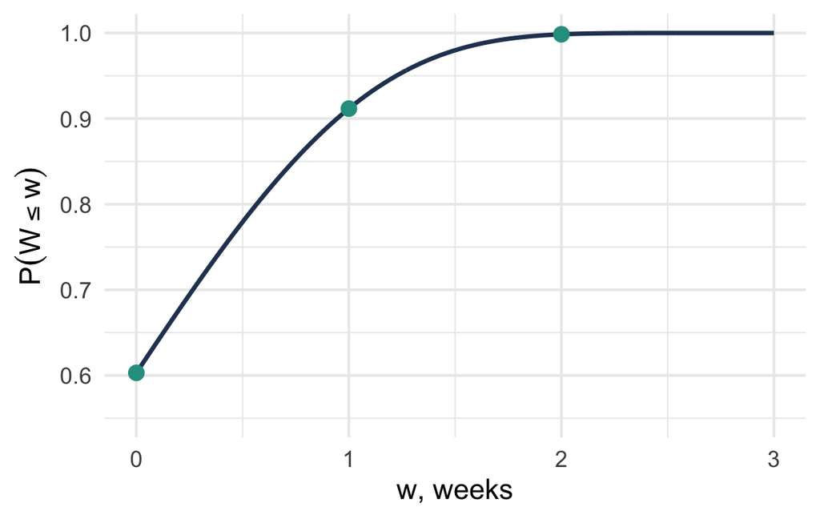

At $w = 0$, $D_0(3)$ has mean 12 and the positions are $10, \ldots, 17$:

$$\begin{aligned}
P(W = 0) &= \tfrac{1}{8}(0.2424 + 0.3472 + \cdots + 0.8987)\\
&= 4.8238/8 = 0.6030
\end{aligned}$$

At $w = 1$ the mean is 8 and the same eight entries sum to 7.2934, so $7.2934/8 =$ **0.9117**; at $w = 2$ the mean is 4, and $7.9878/8 =$ **0.9985**.

*The check.* $P(W = 0)$ is the ready rate. The area under $P(W > w)$ is 0.2575 on a day grid, against 0.2568.

Six requests in ten ship at once, nine in ten within a week, almost none past two weeks. **The mean of 1.8 days hides that shape.**

## The Second Moment of the Wait

Little’s Law has a distributional form (Bertsimas and Nakazato) for Poisson arrivals served first come first served, in **factorial** moments:

$$\begin{aligned}
E\big[B_0(B_0 - 1)\big] &= \lambda_0^{2}\,E[W^{2}]
&&\text{distributional Little's Law}\\
E[W^{2}] &= \frac{E[B_0^{2}] - \bar{B}_0}{\lambda_0^{2}}
&&\text{expand the factorial moment}\\
\mathit{Var}[W] &= \frac{E[B_0^{2}] - \bar{B}_0 - \bar{B}_0^{2}}{\lambda_0^{2}}
= \frac{\mathit{Var}[B_0] - \bar{B}_0}{\lambda_0^{2}}
&&\text{subtract } \bar{W}^{2} = \bar{B}_0^{2}/\lambda_0^{2}
\end{aligned}$$

$\mathit{Var}[B_0]$ is chapter 8’s second moment of the backorder level, built for this use.

**Notice the subtraction.** The variance of the wait is not the variance of the backorder level scaled; it is that variance less the mean.

## The Spread of the Wait, Computed

The running example’s hub runs $(r_0, Q_0) = (9, 8)$ against Poisson demand with mean 12, so its positions are $10, \ldots, 17$ and $\bar{B}_0 = 1.0273$.

$$\begin{aligned}
\textstyle\sum_{j=10}^{17} G^{1}(j) &= 8.2185, \qquad \sum_{j=10}^{17} G^{2}(j) = 15.9041
&&\text{the two loss columns at mean 12}\\
E[B_0^{2}] &= \tfrac{1}{8}\left[2(15.9041) + 8.2185\right] = 5.0033
&&\text{average } 2G^{2}(j) + G^{1}(j)\\
\mathit{Var}[B_0] &= 5.0033 - 1.0273^{2} = 3.9480
&&\text{second moment less squared mean}\\
\mathit{Var}[W] &= \frac{3.9480 - 1.0273}{4^{2}} = 0.1825 \text{ weeks}^{2}
&&\text{the relation above}
\end{aligned}$$

The standard deviation is $\sqrt{0.1825} = 0.427$ weeks, which is 3.0 days, against a mean of 1.8 days.

## Axsäter’s Recursion

Both levels one for one first. Let $C(S_0, S_j)$ represent the system’s cost per week with the hub’s position at $S_0$ and each storeroom’s at $S_j$.

**Track one unit.** A unit the hub orders fills the $S_0$th hub demand after the order, and at the storeroom the $S_j$th demand after that storeroom’s order. Poisson demand makes its cost computable. Let $\pi^{S_j}$ represent the cost per unit at a storeroom whose supplier never runs out, $\Pi^{S_j}(S_0)$ the storeroom’s cost per unit at hub position $S_0$, and $\gamma(S_0)$ the hub’s holding cost per unit. Then $C = \lambda_0\big(\Pi^{S_j}(S_0) + \gamma(S_0)\big)$, and

$$\begin{aligned}
\Pi^{S_j}(S_0 - 1) = {} & \frac{\lambda_j}{\lambda_0}\Pi^{S_j - 1}(S_0)
+ \frac{\lambda_0 - \lambda_j}{\lambda_0}\Pi^{S_j}(S_0)\\
& + \frac{\lambda_j}{\lambda_0}\big(1 - P(D_0(L_0) \ge S_0)\big)\big(\pi^{S_j} - \pi^{S_j - 1}\big)
\end{aligned}$$

started where the hub never runs out. It is exact, it runs down a column, and the chapter refers to Axsäter (1990) for the derivation.

**The costs give the stock levels too.** Every term is linear in the cost rates: set shortage to one and holding to zero, and the “cost” is expected backorders.

## The Recursion’s Inputs Are Chapter 8 Quantities

Three of its inputs are base-stock measures you can already compute:

$$\begin{aligned}
\pi^{S_j} &= \frac{h\,\bar{I}_j(S_j) + b\,\bar{B}_j(S_j)}{\lambda_j}
&&\text{the storeroom alone, lead time } O_j\\
\Pi^{0}(S_0) &= b\left(O_j + \frac{\bar{B}_0(S_0)}{\lambda_0}\right)
&&\text{a storeroom holding nothing: transit plus the wait}\\
\gamma(S_0) &= \frac{h\,\bar{I}_0(S_0)}{\lambda_0}
&&\text{the hub's holding, per unit passing through}
\end{aligned}$$

*A small system.* Two storerooms, $\lambda_j = 1$ a week each, so $\lambda_0 = 2$; $O_j = 1$ and $L_0 = 1$ week; $h = \$0.5529$ and $b = \$5.5288$ per unit per week.

| $S_j$ | $\bar{B}_j(S_j)$ | $\bar{I}_j(S_j)$ | $\pi^{S_j}$ |
| --- | --- | --- | --- |
| 0 | 1.0000 | 0.0000 | 5.5288 |
| 1 | 0.3679 | 0.3679 | 2.2373 |
| 2 | 0.1036 | 1.1036 | 1.1832 |
| 3 | 0.0233 | 2.0233 | 1.2477 |

For example, $\pi^{1} = 0.55288(0.36788) + 5.52885(0.36788) = 0.20339 + 2.03395 = 2.2373$.

## The Recursion, Run by Hand

For $S_j = 1$ the share is $\tfrac{1}{2}$ and $\pi^{1} - \pi^{0} = 2.2373 - 5.5288 = -3.2915$.

$$\begin{aligned}
\Pi^{1}(S_0 - 1) &= \tfrac{1}{2}\,\Pi^{0}(S_0) + \tfrac{1}{2}\,\Pi^{1}(S_0)
+ \tfrac{1}{2}\big(1 - P(D_0 \ge S_0)\big)(-3.2915)
&&\text{this system}\\
\Pi^{1}(11) &= \tfrac{1}{2}(5.5288) + \tfrac{1}{2}(2.2373) + \tfrac{1}{2}(1 - 0.0000)(-3.2915) = 2.2373
&&\text{no tail: nothing moves}\\
\Pi^{1}(2) &= \tfrac{1}{2}(6.1315) + \tfrac{1}{2}(2.6454) + \tfrac{1}{2}(1 - 0.3233)(-3.2915) = 3.2748
&&\text{from } S_0 = 3
\end{aligned}$$

| $S_0$ | $P(D_0 \ge S_0)$ | $\bar{B}_0$ | $\Pi^{0}$ | $\Pi^{1}$ | $\Pi^{2}$ | $\Pi^{3}$ | $\gamma$ | $C(S_0, 3)$ |
| --- | --- | --- | --- | --- | --- | --- | --- | --- |
| 4 | 0.1429 | 0.0751 | 5.7366 | 2.3755 | 1.2394 | 1.2549 | 0.5737 | 3.6571 |
| 3 | 0.3233 | 0.2180 | 6.1315 | 2.6454 | 1.3556 | 1.2748 | 0.3367 | 3.2230 |
| 2 | 0.5940 | 0.5413 | 7.0253 | 3.2748 | 1.6439 | 1.3370 | 0.1496 | **2.9734** |
| 1 | 0.8647 | 1.1353 | 8.6674 | 4.4819 | 2.2453 | 1.5035 | 0.0374 | 3.0819 |

Each column is built from the one to its left. Lowering the hub from 3 to 2 raised the storeroom’s cost per unit from $2.65 to $3.27, and $C(2, 3) = 2(1.33703 + 0.14965) = \$2.9734$ a week is the cheapest pair.

## The Hub Batches: Equation (1)

A hub order of $Q_0$ units: the $k$th fills the $(r_0 + k)$th hub demand after the order, as if the hub ran base stock at $S_0 = r_0 + k$. Averaging over a batch’s units is averaging over the hub’s positions:

$$C = \frac{1}{Q_0}\sum_{S_0 = r_0+1}^{r_0+Q_0} C(S_0, S_j)$$

The chapter’s move, a second time.

*The running example,* $S_j = 3$, hub positions $10, \ldots, 17$:

| $S_0$ | 10 | 11 | 12 | 13 | 14 | 15 | 16 | 17 |
| --- | --- | --- | --- | --- | --- | --- | --- | --- |
| $C(S_0, 3)$ | 7.2105 | 6.7516 | 6.5493 | 6.5587 | 6.7352 | 7.0373 | 7.4296 | 7.8837 |

Each is $\lambda_0(\Pi^{3} + \gamma)$: at $S_0 = 12$ the hub’s part is $\gamma = 0.5529(1.3724)/4 = 0.1897$. Average: $56.1559/8 = \$7.0195$ a week. With the backorder-only rates the same recursion gives 0.2906 backorders across four storerooms, **0.0726 at each**.

*The check.* The recursion’s hub on-hand is 2.5273, the $\bar{I}_0$ computed from chapter 8 by an entirely different route.

## Three Routes to a Storeroom’s Lead Time Demand

The storeroom’s lead time is $O_j + W$. Three ways to feed chapter 8:

1. **The mean wait only.** Poisson with mean $\lambda_j(O_j + \bar{W})$: METRIC’s move.
2. **Two moments.** A negative binomial with mean $\lambda_j(O_j + \bar{W})$ and variance $\lambda_j(O_j + \bar{W}) + \lambda_j^{2}\mathit{Var}[W]$: VARI-METRIC’s.
3. **Conditioned on the wait.** For each $w$, Poisson with mean $\lambda_j(O_j + w)$, averaged over the wait’s distribution: the chapter’s move, a third time.

Which of the three matches Axsäter’s exact 0.0726?

| Route | Backorders per storeroom | Against exact |
| --- | --- | --- |
| Conditioned on the wait | 0.0726 | exact |
| Two moments | 0.0712 | 2% low |
| The mean wait only | 0.0505 | 30% low |

**Conditioning is exact here.** With first come first served and $r_0 \ge 0$, a request’s wait is fixed by what happened before it arrived, and the storeroom’s later customers are independent of all that. The linked waits of week 11 are real, but for a base-stock storeroom they do not matter.

## What We Did Today

**A batching location passes up something other than its demand.** Condition on the position, then average, carries the chapter.

**The ledger showed one delivery clearing three requests,** a mean wait of 0.667 weeks by two routes, and crews waiting because the hub did.

**With one-at-a-time storerooms the hub is a chapter 8 location:** 60% ready, by design.

**The wait’s whole distribution comes from the lead-time shift,** and its variance from the distributional Little’s Law.

**Axsäter’s recursion is exact,** and conditioning on the wait matches it; the mean alone is 30% low.

## For Next Time

**Read before next session:** *When the Storerooms Batch Too*, *Orders in a Window*, *The Hub With Other Demand*, *The Storeroom Behind a Batching Hub* and *Random Lead Times*.

Today’s material was the chapter’s opening through *Exact Storeroom Measures*.

Next session:

- Storerooms that batch, and where Axsäter’s exact method ends
- Counting a storeroom’s orders in a window, from the Poisson table
- A hub with other demand, the wait of an order, and a supplier whose lead time varies

Next session the hub’s demand stops being Poisson. Bring the order-count idea: the position, again, is uniform.

⌂ Index